# Module 4 Lecture - States of Consciousness

Introductory Psychology

Quinton Quagliano, M.S., C.S.P

Department of Psychology

# 1 Overview and Introduction

Agenda

1 Overview and Introduction

2 What is Consciousness?

3 Sleep and Why We Sleep

4 Stages of Sleep

5 Sleep Problems and Disorders

6 Conclusion

## 1.1 Textbook Learning Objectives

- Understand what is meant by consciousness
- Explain how circadian rhythms are involved in regulating the sleep-wake cycle, and how circadian cycles can be disrupted
- Discuss the concept of sleep debt
- Describe areas of the brain involved in sleep
- Understand hormone secretions associated with sleep
- Describe several theories aimed at explaining the function of sleep
- Name and describe three theories about why we dream
- Differentiate between REM and non-REM sleep
- Describe the differences between the three stages of non-REM sleep
- Understand the role that REM and non-REM sleep play in learning and memory
- Describe the symptoms and treatments of insomnia
- Recognize the symptoms of several parasomnias
- Describe the symptoms and treatments for sleep apnea
- Recognize risk factors associated with sudden infant death syndrome (SIDS) and steps to prevent it
- Describe the symptoms and treatments for narcolepsy

## 1.2 Instructor Learning Objectives

- Understand how consciousness is better described as range of states, rather than simply “on” or “off”
- Appreciate the complex biological and systemic changes at play in sleep regulation

## 1.3 Introduction

- Have you ever been in the back of a classroom, watching a boring lecture, slowly feeling yourself falling asleep?
  - We’ve all been there…
  - All of us have had the experience of being wide awake, being tired/fatigued, being asleep, etc.
- **Discuss: Write about how many hours of sleep do you get each night, and if you regularly feel awake or tired? This is a little preview of what we'll be talking about today**
- There are other states of conciousness, related to use of specific substances or intentional disassociation
  - These will not be a major focus in this lecture, relative to sleep

# 2 What is Consciousness?

Agenda

1 Overview and Introduction

2 What is Consciousness?

3 Sleep and Why We Sleep

4 Stages of Sleep

5 Sleep Problems and Disorders

6 Conclusion

## 2.1 Introduction

- **Important: There is a philosophical debate to have on what exactly 'consciousness' is - we are going to try to stay more focused on a factual concrete description today, but it is worth reading into more!**
- **Consciousness** is our state of awareness of our environment, perceptions, and thoughts.
  - On the other hand, we have the state of being unconcious or being un-alert to the world around us
- When we are awake, we are usually at least reasonably conscious of our surroundings, but when we are **sleeping** we are more-or-less completely unaware
  - But between these two states, we have things like tiredness, daydreaming, being intoxicated with substances, being knocked unconscious due to injury, etc.

## 2.2 Biological Rhythms

- Our bodies run on many rhythmic biological processes:
  - Each of these is a **circadian rhythm**, or one that has a cyclical function over 24 hours
  - Sleep and awake
  - Body temperature natural fluctuations
  - Menstrual cycles
  - Many others
- **Important: Many of these cycles tie back in nicely to biopsychology, but we will primarily focus on sleep and its biological basis for this lecture.**

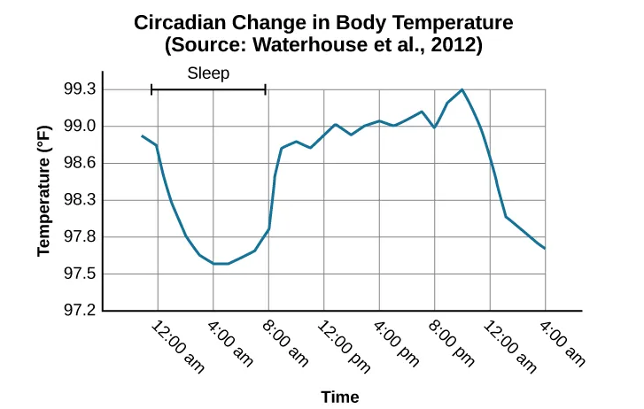

- Our bodies attempt to maintain **homeostasis**, which is a restful, optimal state in which hormones, cells, substances, and other bits of our body are in balance
  - Homeostasis is our ideal state, which is healthy for us
  - All of these cycles and circadian rhythms help this process of homeostasis
- Our brain has built-in clock called the **suprachiasmatic nucleus (SCN)** in the hypothalamus
  - However, one nuance of this structure is that it is connected to the detection of light (usually sunlight). Constant light or lack thereof could possible disrupt proper function.
  - This is one reason people may opt to use “light boxes” or “blackout” curtains

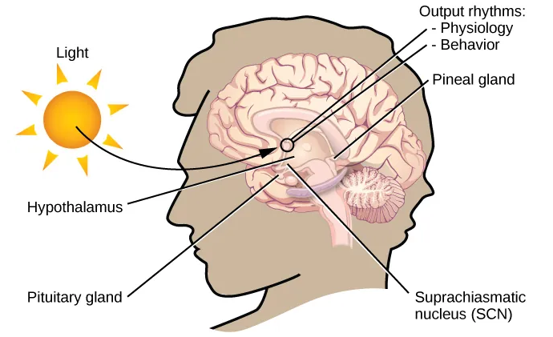

- **Discuss: What part of the CNS is the hypothalamus located in and what organ in the endocrine system does it coordinate hormone production with?**

## 2.3 Problems with Circadian Rhythms

- Ideally, our circadian rhythm related to sleep has us awake during the daytime and asleep during the night
- This is aided, in part, by the production of **melatonin** by the pineal gland in the endocrine system.
  - A rule of thumb: melatonin is produced more when we are in darkness, which is determined in part by the SCN
- **Important: Everything is connected! The SCN is located in the hypothalamus, which conducts hormone regulation with the pituitary gland which in turn conducts the pineal gland which produces melatonin in response to the original darkness sensed by the SCN.**
- There are regular and healthy individual difference in exact tiredness pattern
  - I, your instructor, am more of a morning person, up at 4am and falling asleep early (ideally)
  - Some people are more “night owls”
  - Neither of these is bad, in moderation
  - Our exactly **sleep regulation** is how we switch between sleep and wakefulness

## 2.4 Temporary Disruptions of Normal Sleep

- There are several temporary circumstances that disrupt or otherwise harm our circadian rhythm of sleep
  - **Jet lag** is a term that describes a temporary condition after crossing multiple time zones quickly (usually on a flight)
  - **Insomnia** is difficulty in falling and staying asleep for long periods of time
  - **Rotating shift work or working late hours** can also impact our sleep, as we may be exposed to less light than what the human body is accustomed too
- **Discuss: Try thinking of some other scenarios where sleep and restfulness is otherwise harmed**

## 2.5 Insufficient Sleep

- Many of us do not get enough sleep (wow, shocker!)
  - This results in what we call **sleep debt**, or a lack of sleep causing residual negative symptoms
  - Rise in this has been attributed, in part, to the development of artificial light
- **Important: Remember that SCN? It gets impacted by artificial light similar to sunlight...**

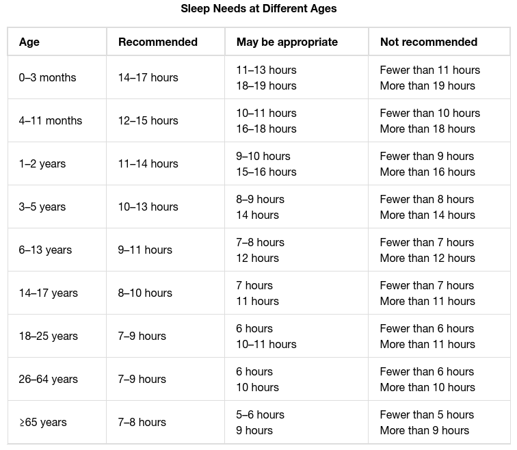

- Chronic sleep debt can lead to:
  - Mental health concerns (especially depression and irritability )
  - Slowed processing speed and diminished attention
  - Extreme cases can lead to pseudo-intoxication at around 24 hours, hallucinations at 48 hours, and eventual death (in the case of fatal insomnia)

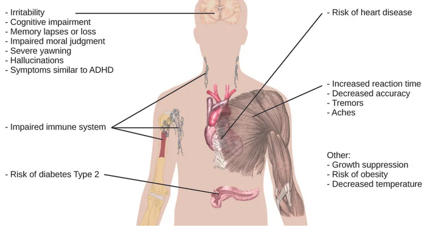

# 3 Sleep and Why We Sleep

Agenda

1 Overview and Introduction

2 What is Consciousness?

3 Sleep and Why We Sleep

4 Stages of Sleep

5 Sleep Problems and Disorders

6 Conclusion

## 3.1 Introduction

- Species differ in how much sleep they get, if any, but humans need to sleep around 32 percent of our lives
- **Important: That is a ton of time! But evidence shows we really do need this much.**

## 3.2 What is Sleep?

- A perfect definition of sleep is hard to pin down, but:
  - It is governed by a circadian rhythm
  - It is necessary for homeostasis
  - It is a time of relatively low physical and concious cognitive activity
- Connecting back to biopsychology, there’s a few areas of the brain involved:
- The pons is involved in REM (more on that in a bit)
- The thalamus coordinates “slow wave” sleep
- Hypothalamus and contained SCN keep our biological clock correct
- Pituitary gland secretes growth hormone which is often active during sleep

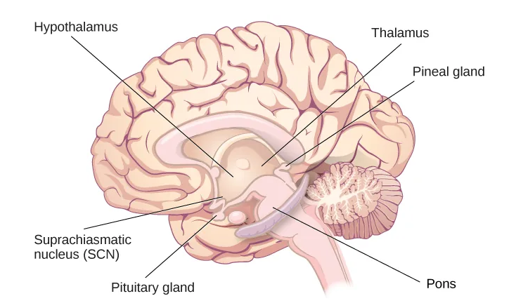

- **Question: What part of the brain is the pons located in?**
- A) Forebrain
- B) Hindbrain
- C) Midbrain
- D) Spinal Cord

## 3.3 Why Do We Sleep?

- **Important: Sleep is clearly important, but why? That is actually still a question up for debate**
- This is a super cool area of research in psychology, because there is still so much not well-understood in sleep
- But, we can understand a bit about why we need sleep by looking at the functions it appears to serve and evidence of certain correlates with it

## 3.4 Adaptive Function of Sleep

- The adaptive functions of sleep are often viewed through the lens of evolutionary psychology
- **Discuss: Review: describe the focus of evolutionary psychology - what is it primarily concerned with?**
- Be careful of non-scientific, intuitive claims, even those that seem to make sense in the evolutionary scheme
  - Hypothesis 1: Sleep is adaptive to help conserve energy - evidence shows that this doesn’t really seem to be correlated
  - Hypothesis 2: Sleep in safe spaces keeps us safe from predators - but doesn’t seem to hold up in animal models
- Even if there is not a clear evolutionary reason why we sleep, research suggests that there are benefits:
  - Lowered stress
  - Better overall physical health
  - Better mood
  - Improved memory and other cognitive skills

## 3.5 Cognitive Function of Sleep

- Speaking of memory, evidence on learning and formation of memories seems to imply that proper sleep is essential for maintaining memory
- **Discuss: If we say that more high quality sleep and better memory function are correlated with r = 0.95 (hypothetically), how do we describe this relationship?**
- It seems sleep may also benefit creative thinking and language learning as well

# 4 Stages of Sleep

Agenda

1 Overview and Introduction

2 What is Consciousness?

3 Sleep and Why We Sleep

4 Stages of Sleep

5 Sleep Problems and Disorders

6 Conclusion

## 4.1 Introduction

- As alluded to earlier, sleepiness is not an on-off switch, it is better thought of as a gradient of several different stages and states

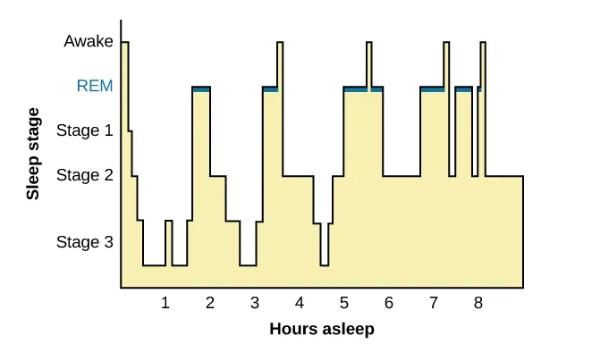

- When awake, our brain primarily shows **beta waves** on an EEG
  - These waves are quick, small (low amplitude) bumps on a graph
- **Question: What method does an EEG work on for imaging the brain?**
- A) Magnets
- B) Radiation
- C) Electricity
- D) None of the above
- We have 4 distinct stages of sleep: stages 1, 2, 3 and REM (covered more in the next section)

## 4.2 NREM Stages of Sleep

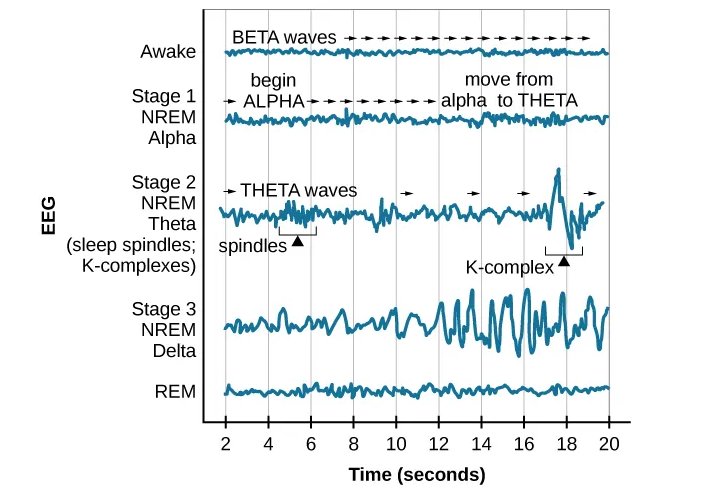

- Stage 1
  - Feels almost like you aren’t even asleep - more so just very relaxed
  - Alpha waves with slightly larger amplitudes
  - Eventually transition to theta waves with even larger amplitudes
- Stage 2
  - Deeper sleep and relaxation
  - Now have **sleep spindles** with bursts of rapid activity, thought to be related to memory and learning
  - Also **k-complexes** that seem to do with staying aware of surroundings

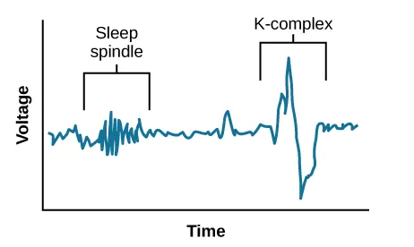

- Stage 3
  - Very deep sleep that should contain large **delta waves**
  - Being woken up from this state results in being very groggy
- **Discuss: Many people experience 'hypnic jerks' or a sudden quick muscle spasm associated with feelings of falling, what stage do you think that occurs in?**

## 4.3 REM Sleep

- **REM (Rapid Eye Movement) Sleep** is marked by high levels of brain activity similar to when we are awake
  - This is why it is sometimes called paradoxical sleep
  - Accompanied by muscle paralysis to protect the sleeper; this is also what results in “sleep paralysis”

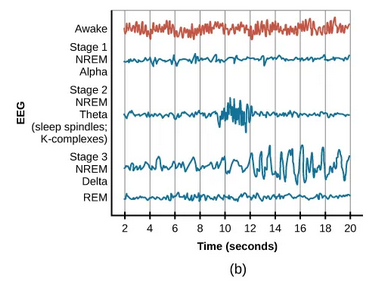

- REM is still being explored but has fascinating characteristics that suggests it is extraordinarily important for emotion regulation and memory

## 4.4 Dreams

- Dreams and interpreting their meaning have long been an area of interest and controversy
- **Question: Sigmund Freud was one of the earliest psychological theorists on dreams, what historical perspective of psychology is he associated with?**
- A) Psychoanalysis
- B) Developmental
- C) Behaviorism
- D) Functionalism
- Freud’s perspective is that there were two parts of dreams:
  - The **manifest content**, the actual content and happenings of the dreams
  - The **latent content**, the interpretation of the dream
- **Important: Remember, Freud is criticized for being a bit pre-scientific in his findings at times...**

# 5 Sleep Problems and Disorders

Agenda

1 Overview and Introduction

2 What is Consciousness?

3 Sleep and Why We Sleep

4 Stages of Sleep

5 Sleep Problems and Disorders

6 Conclusion

## 5.1 Introduction

- There are several known, chronic conditions that present more severe and sustained problems than the temporary scenarios discussed earlier
- These sleep disturbances have different mechanisms that change the function of the sleep waves as described prior and require specialized treatment
- **Important: Talk with your doctor if one of these conditions personally affects you and you would like to seek treatment. I am not a physician and none of the following is medial advice!**

## 5.2 Insomnia

- **Insomnia** is the difficulty in falling and staying asleep
  - It may appears as tossing and turning in bed, feeling “wired”, waking up often, finding it difficult to relax, etc.
  - Tends to be very stressful, which only further increases the difficulty in sleeping
  - Multi-factoral and not always one clear cause: may by psychological, related to medications, related to current events, etc.
- Treatment is best done with **Cognitive-behavioral Therapy (CBT)** which focuses on stress management and changing harmful behaviors
  - There also exists temporary aids, i.e., “sleeping pills”
- **Discuss: Have you ever experienced strange things while taking sleep aids, e.g., Nyquil**

## 5.3 Parasomnias

- **Parasomnias** involves involuntary and unwanted motor activity, that comes in several flavors
  - These can happen across NREM or REM sleep

### Sleepwalking

- **Sleepwalking aka somnambulism** generally occurs during slow-wave sleep and is linked to breathing problem
  - Sometimes this can involve surprisingly complex (and dangerous) behaviors
  - Safest thing to do is wake the person up and guide them back to bed
- **Discuss: Know of any stories of sleepwalking friends or family (or yourself)**

### REM Sleep Behavior Disorder (RBD)

- This involves the improper paralyzing of muscles during REM. Because REM involves very “active” brain waves this may result in:

> These behaviors vary widely, but they can include kicking, punching, scratching, yelling, and behaving like an animal that has been frightened or attacked. People who suffer from this disorder can injure themselves or their sleeping partners when engaging in these behaviors.

### Other Parasomnias

- **Restless leg syndrome** as the name would imply involves involuntary movement in the legs that make it difficult to fall and stay asleep
- **Night terrors** similarly intuitive name, are a sudden sense of panic in the sufferer and are often accompanied by screams and attempts to escape from the immediate environment.

## 5.4 Sudden Infant Death Syndrome (SIDS)

- **SIDS** tends to occur in infants younger than 12 months old, occurring seemingly at random
  - It is best to put infants on their back to sleep and to take precaution to avoid anything in cribs that may cause suffocation like additional blankets/pillows

# 6 Conclusion

Agenda

1 Overview and Introduction

2 What is Consciousness?

3 Sleep and Why We Sleep

4 Stages of Sleep

5 Sleep Problems and Disorders

6 Conclusion

## 6.1 Recap

- There are many important circadian and homeostasis-focused rhythms/cycles in our bodies that help keep us physiologically and psychologically healthy
- Sleep is one of these rhythms, and is a complex but important process that is essential for proper regulation of memory, emotion, physical health, and overall cognition
- Sleep has multiple stages and components, each with distinct characteristics and brain wave activities
- Unfortunately, sleep can be both temporarily and chronically disrupted in manners that are dangerous to our well-being

## 6.2 Lecture Check-in

- Get into assigned groups for our weekly group work activity!

[figure not shown]

Module 4 Lecture - States of Consciousness || Introductory Psychology